# Project Description

In this project, we explore both local and international markets to discover opportunities for fitness products. We use data manipulation techniques to analyze information about online interest in home gyms, gym workouts, home workouts, and various fitness products. Our goal is to create clear visualizations that help us make informed decisions about which products to focus on.

We aim to understand the current demand for digital fitness classes. To do this, we conduct a market analysis using Python to measure demand and find potential areas for growth in digital fitness products and services.

### The Data

Our data comes from several CSV files containing information on Google Trends keyword searches related to fitness. These files provide both international and country-level data.

### workout.csv

| Column | Description |
| --- | --- |
| `month` | The month when the data was collected. |
| `workout_worldwide` | Popularity index of the keyword "workout" on a scale from 0 to 100. |

### three_keywords.csv

| Column | Description |
| --- | --- |
| `month` | The month when the data was collected. |
| `home_workout_worldwide` | Popularity index of the keyword "home workout" on a scale from 0 to 100. |
| `gym_workout_worldwide` | Popularity index of the keyword "gym workout" on a scale from 0 to 100. |
| `home_gym_worldwide` | Popularity index of the keyword "home gym" on a scale from 0 to 100. |

### workout_geo.csv

| Column | Description |
| --- | --- |
| `country` | The country where the data was collected. |
| `workout_2018_2023` | Popularity index of the keyword "workout" over the five-year period from 2018 to 2023. |

### three_keywords_geo.csv

| Column | Description |
| --- | --- |
| `country` | The country where the data was collected. |
| `home_workout_2018_2023` | Popularity index of the keyword "home workout" over the five-year period from 2018 to 2023. |
| `gym_workout_2018_2023` | Popularity index of the keyword "gym workout" over the five-year period from 2018 to 2023. |
| `home_gym_2018_2023` | Popularity index of the keyword "home gym" over the five-year period from 2018 to 2023. |

```python
# import the libraries
import pandas as pd
import matplotlib.pyplot as plt
```

### When was the global search for 'workout' at its peak?

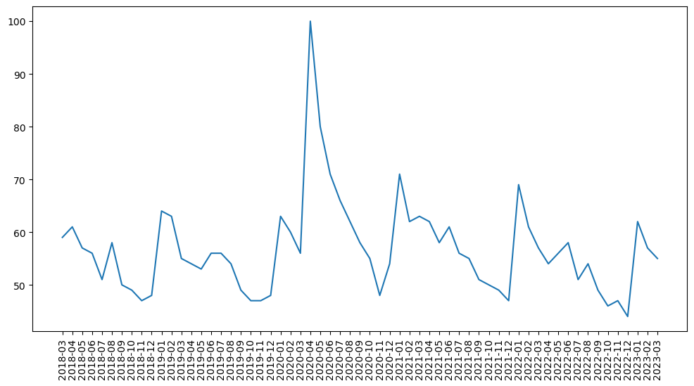

```python
df_workout = pd.read_csv('workout.csv')

# using lineplot to see the trend
plt.figure(figsize=(12, 6))
plt.plot(df_workout["month"], df_workout["workout_worldwide"])
plt.xticks(rotation=90)
plt.show()
```

```python
year_str = "2020"
```

### Find the most popular keywords for the current year and during covid

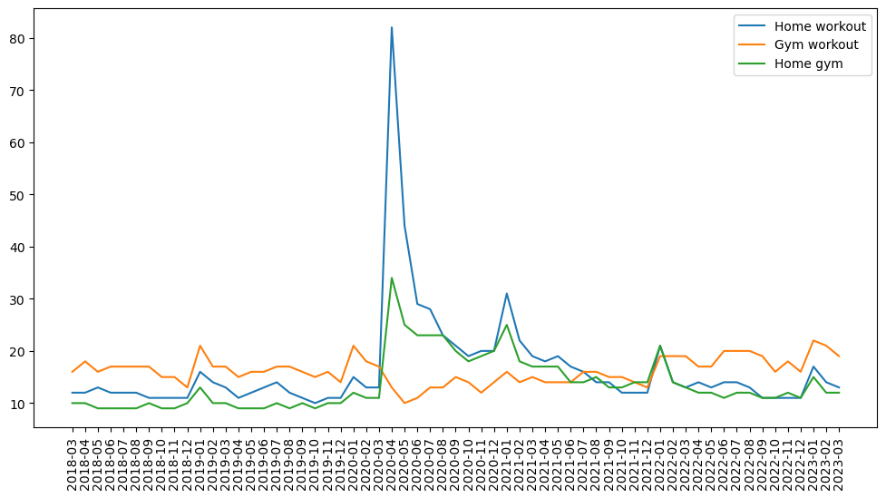

```python
df_keywords = pd.read_csv("three_keywords.csv")

plt.figure(figsize=(12, 6))
plt.plot(df_keywords["month"], df_keywords["home_workout_worldwide"], label="Home workout")
plt.plot(df_keywords["month"], df_keywords["gym_workout_worldwide"], label="Gym workout")
plt.plot(df_keywords["month"], df_keywords["home_gym_worldwide"], label="Home gym")
plt.xticks(rotation=90)
plt.legend()
plt.show()
```

```python
peak_covid = "home workout"
current = "gym workout"
```

### What country has the highest interest for workouts among the following: United States, Australia, or Japan?

```python
# country with the highest interest for workouts
df_workout_geo = pd.read_csv("workout_geo.csv", index_col = 0)
print(df_workout_geo.loc["United States"])
print(df_workout_geo.loc["Australia"])
print(df_workout_geo.loc["Japan"])
```

```
workout_2018_2023    100.0
Name: United States, dtype: float64
workout_2018_2023    77.0
Name: Australia, dtype: float64
workout_2018_2023    1.0
Name: Japan, dtype: float64
```

```python
top_country = "United States"
```

### We are interested in expanding your virtual home workouts offering to either the Philippines or Malaysia. Which of the two countries has the highest interest in home workouts?

```python
# the highest interest in home workouts, Philippines or Malaysia?
df_keywords_geo = pd.read_csv("three_keywords_geo.csv", index_col = 0)
print(df_keywords_geo.loc["Philippines", :])
print(df_keywords_geo.loc["Malaysia", :])
```

```
home_workout_2018_2023    52.0
gym_workout_2018_2023     38.0
home_gym_2018_2023        10.0
Name: Philippines, dtype: float64
home_workout_2018_2023    47.0
gym_workout_2018_2023     38.0
home_gym_2018_2023        15.0
Name: Malaysia, dtype: float64
```

```python
home_workout_geo = "Philippines"
```

### By analyzing and exploring the data deeper, we can answer many more quuestions. Thank you!